# Lab 1 – Review of R

## Indexing

Suppose we have a vector “x” and would like to extract the element in its second position and assign it to a new object called “b”:

```r
x <- 5:10
b <- x[2]
b
```

```
## [1] 6
```

The square brackets, `[` and `]`, are used to access a certain position (or multiple positions) within an object. In this example we access the second position of the object “x”. Note that R is a 1-indexed language not a 0-indexed language (e.g. C). The first index is 1.

Some objects, such as data frames, have multiple dimensions, requiring indices in each dimension (separated by commas) to describe a single element. A few examples are shown below:

```r
DF <- data.frame(x = x, y = y, z = z)
DF[2,3] # The element in row 2, column 3
```

```
## [1] "B"
```

```r
DF[2,] # Everything in row 2
```

```
##   x y z
## 2 6 2 B
```

For list objects, double square brackets, `[[`, are used to access positions within the list:

```r
my_list[[2]] ## The 2nd component of the list
```

```
##   A B C
## 1 1 1 A
## 2 2 2 B
## 3 3 3 C
```

**Question 4**: Use indices to print the Happiness score (column #3) of Hong Kong (row #57) in the object `my_data` (the Happy Planet data from Question 1). Be sure your code does not print any other information about this observation.

## Working with Data

Suppose we want to access a single variable from a data set, there are a few different ways we can do so:

```r
# The $ accesses the component named 'Country' within 'my_data'
countries <- my_data$Country

# Position indexing to access the variable 'Country' (since its the first column)
countries2 <- my_data[,1]

# Use the name of the variable in place of an index position
countries3 <- my_data[,'Country']
```

Suppose we want to access a single observation (data point) in our dataset:

```r
Albania <- my_data[1,] # This stores the entire first row
```

Suppose we want a range of observations:

```r
FirstFive <- my_data[1:5,] # This stores the first five rows
head(FirstFive)
```

```
##     Country Region Happiness LifeExpectancy Footprint  HLY   HPI HPIRank
## 1   Albania      7       5.5           76.2       2.2 41.7 47.91      54
## 2   Algeria      3       5.6           71.7       1.7 40.1 51.23      40
## 3    Angola      4       4.3           41.7       0.9 17.8 26.78     130
## 4 Argentina      1       7.1           74.8       2.5 53.4 58.95      15
## 5   Armenia      7       5.0           71.7       1.4 36.1 48.28      48
##   GDPperCapita   HDI Population
## 1         5316 0.801       3.15
## 2         7062 0.733      32.85
## 3         2335 0.446      16.10
## 4        14280 0.869      38.75
## 5         4945 0.775       3.02
```

The `head` function prints the first few rows and variables of an object. Here are a few other functions might use when working with a new data set:

```r
dim(my_data) # prints the dimensions of 'my.data'
```

```
## [1] 143  11
```

```r
nrow(my_data) # prints the number of rows of 'my.data'
```

```
## [1] 143
```

```r
ncol(my_data) # prints the number of columns of 'my.data'
```

```
## [1] 11
```

```r
colnames(my_data) # prints the names of the variables (columns) of 'mydata'
```

```
##  [1] "Country"        "Region"         "Happiness"      "LifeExpectancy"
##  [5] "Footprint"      "HLY"            "HPI"            "HPIRank"
##  [9] "GDPperCapita"   "HDI"            "Population"
```

**Question 5A**: Write code that prints the populations of the last three observations (countries) that appear in the Happy Planet data.

**Question 5B**: Write code that finds the median value of the “LifeExpectancy” variable for the last 10 observations in the Happy Planet data.

## Logical Conditions and Subsetting

Often we want to access all data that meet certain criteria. For example, we may want to analyze all countries with a life expectancy above 80. To accomplish this, we’ll need to use logical operators:

```r
## This returns a logical vector using the condition "> 80"
my_data$LifeExpectancy > 80
```

A few logical operators you should know of are:

Operator | Description

`==` | equal to

`!=` | not equal to

`>` | great than

`>=` | greater than or equal to

`<`| less than

`<=|` less than or equal to

`&`| and

`|` | or

`!` | negation (“not”)

The `which()` function can be used to identify the indices of elements of within an object containing the logical value `TRUE`, for example:

```r
## This returns the positions where the condition evaluated to TRUE
which(my_data$LifeExpectancy > 80 )
```

This result could then be used as indices to subset `my_data`:

```r
## sub-setting via indices
keep_idx <- which(my_data$LifeExpectancy > 80)
my_subset <- my_data[keep_idx, ]
```

The approach shown above is a bit cumbersome. As an alternative we can use the `subset()` function alongside logical expressions:

```r
## Example #1
Ex1 <- subset(my_data, LifeExpectancy > 80)
```

In example #1, the data frame `Ex1` will contain the subset of countries with life expectancy above 80. Notice how the `subset()` function knows that `LifeExpectancy` is a component of `my_data`.

```r
## Example #2
Ex2 <- subset(my_data, LifeExpectancy <= 70 & Happiness > 6)
```

In example #2, the `&` operator is used to create a data frame, `Ex2`, containing all countries with a life expectancy of 70 or below *and* a happiness score above 6.

```r
## Example #3
Ex3 <- subset(my_data, LifeExpectancy <= 70 | Happiness > 6)
```

In example #3, the `|` operator is used create a data frame of all countries with a life expectancy of 70 *or* below or a happiness score above 6. Notice the different dimensions of `Ex2` and `Ex3`:

```r
dim(Ex2)
```

```
## [1]  9 11
```

```r
dim(Ex3)
```

```
## [1] 118  11
```

**Question 6**: Create a data frame named “Q6” that contains all countries with a population over 100 million that also have a happiness score of 6 or lower. Then, print the number of rows of this data frame.

## Data Summaries

Descriptive summaries are an essential component of any data analysis. A few functions used to calculate several basic numerical summaries are shown below:

```r
mean(my_data$LifeExpectancy) # mean
```

```
## [1] 67.83846
```

```r
sd(my_data$LifeExpectancy) # standard deviation
```

```
## [1] 11.04193
```

```r
min(my_data$LifeExpectancy) # minimum
```

```
## [1] 40.5
```

```r
max(my_data$LifeExpectancy ) # maximum
```

```
## [1] 82.3
```

```r
quantile(my_data$LifeExpectancy, probs = .35) # the 35th percentile
```

```
##   35%
## 66.18
```

Each of these functions operates on a single variable. For a broader set of summary statistics, you can input an entire data frame into the `summary()` function:

```r
summary(my_data)
```

```
##    Country              Region        Happiness     LifeExpectancy
##  Length:143         Min.   :1.000   Min.   :2.400   Min.   :40.50
##  Class :character   1st Qu.:2.000   1st Qu.:5.000   1st Qu.:61.90
##  Mode  :character   Median :4.000   Median :5.900   Median :71.50
##                     Mean   :3.832   Mean   :5.919   Mean   :67.84
##                     3rd Qu.:6.000   3rd Qu.:7.000   3rd Qu.:76.05
##                     Max.   :7.000   Max.   :8.500   Max.   :82.30
##
##    Footprint           HLY             HPI           HPIRank
##  Min.   : 0.500   Min.   :11.60   Min.   :16.59   Min.   :  1.0
##  1st Qu.: 1.300   1st Qu.:31.10   1st Qu.:34.47   1st Qu.: 36.5
##  Median : 2.200   Median :41.80   Median :43.60   Median : 72.0
##  Mean   : 2.877   Mean   :41.38   Mean   :43.38   Mean   : 72.0
##  3rd Qu.: 3.850   3rd Qu.:53.20   3rd Qu.:52.20   3rd Qu.:107.5
##  Max.   :10.200   Max.   :66.70   Max.   :76.12   Max.   :143.0
##
##   GDPperCapita        HDI           Population
##  Min.   :  667   Min.   :0.3360   Min.   :   0.290
##  1st Qu.: 2107   1st Qu.:0.5790   1st Qu.:   4.455
##  Median : 6632   Median :0.7720   Median :  10.480
##  Mean   :11275   Mean   :0.7291   Mean   :  44.145
##  3rd Qu.:15711   3rd Qu.:0.8680   3rd Qu.:  31.225
##  Max.   :60228   Max.   :0.9680   Max.   :1304.500
##  NA's   :2       NA's   :2
```

Notice how `summary()` is not particularly useful for *categorical* variables. For these variables you should be using frequency tables.

A *one-way frequency table* shows the frequencies of categories in a single categorical variable, while a *two-way frequency table* shows the relationship between two categorical variables. Both are created by the `table()` function:

```r
table(my_data$Region) # A one-way frequency table of 'region'
```

```
##
##  1  2  3  4  5  6  7
## 24 24 16 33  7 12 27
```

```r
table(my_data$Region, my_data$LifeExpectancy > 80) # A two-way frequency table showing the number of countries w/ LifeExpectancy > 80 by region
```

```
##
##     FALSE TRUE
##   1    24    0
##   2    16    8
##   3    15    1
##   4    33    0
##   5     7    0
##   6    10    2
##   7    27    0
```

```r
# Notice how the table function can use numeric, logical, and character variables
```

Tables are their own type of object, and they can be used as an input to functions like `barplot()`:

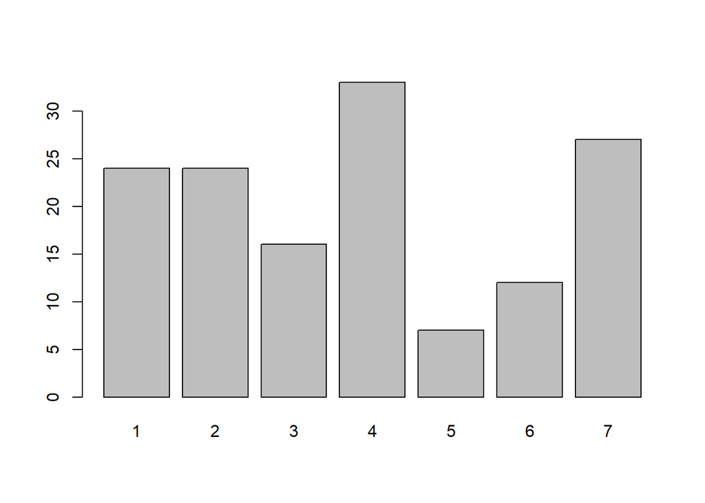

```r
my_table <- table(my_data$Region) # Tables can be stored as objects
barplot(my_table) # Creates a bar plot from a table
```

They can also be used as an input to the `prop.table()` function to find row or column proportions:

```r
prop.table(my_table, margin = 1) # "margin = 1" gives row props, "margin = 2" gives column props
```

```
##
## 1 2 3 4 5 6 7
## 1 1 1 1 1 1 1
```

In the example above, the table only had a single dimension (so each row total was the same as the frequency). Shown below is a more typical example:

```r
my_table <- table(my_data$Region, my_data$LifeExpectancy > 80)
prop.table(my_table, margin = 1)
```

```
##
##         FALSE      TRUE
##   1 1.0000000 0.0000000
##   2 0.6666667 0.3333333
##   3 0.9375000 0.0625000
##   4 1.0000000 0.0000000
##   5 1.0000000 0.0000000
##   6 0.8333333 0.1666667
##   7 1.0000000 0.0000000
```

Notice how this example used a logical condition to construction a binary variable to serve as the columns in the table.

**Question 7**: Find the mean, median, and range (maximum - minimum) of the variable `LifeExpectancy` in the Happy Planet data. Briefly comment on whether the distribution of this variable seems to be symmetric or skewed using plain text beneath your answer’s code chunk.

## Coercion

Earlier we introduced three important types of vectors:

1. numeric vectors - for example: `x = c(1,2,3)`
2. character vectors - for example: `x = c("A","B","C")`
3. logical vectors - for example: `x = c(TRUE, FALSE, TRUE)`

Many functions require their inputs be of a certain type. Fortunately, data can be *coerced* into another type using the `as.` family of functions:

```r
## A character vector where the text strings are numbers
x <- c("1","12","123")
typeof(x)
```

```
## [1] "character"
```

```r
## Coerce 'x' to a numeric vector
x <- as.numeric(x)
x
```

```
## [1]   1  12 123
```

```r
typeof(x)
```

```
## [1] "double"
```

**Question 8**: Coerce the variable “Region” into a character variable. Use the `typeof` function to verify the change. *Hint*: you should overwrite the “Region” vector within “my_data” as part of this question.

## Missing Data

Real data sometimes contain **missing values**, which `R` stores as the special element `NA`. Missing values may be present in your raw data, but they can also be introduced by coercion or other operations/functions:

```r
## The second element is a blank space
x <- c("1"," ","123")
typeof(x)
```

```
## [1] "character"
```

```r
## Coerce to a numeric vector (stored as 'y'), notice the NA
y <- as.numeric(x)
y
```

```
## [1]   1  NA 123
```

Missing values can cause problems for many functions, but some functions have arguments that control how missing values are handled. The example below shows how to remove any missing values when calculating the mean of `y`:

```r
mean(y) ## Doesn't handle the missing value
```

```
## [1] NA
```

```r
mean(y, na.rm = TRUE) ## Removes the missing value
```

```
## [1] 62
```

If missing values are removed in any part of an analysis, you should track and report the identities of the cases that were excluded. You can use the `is.na()` function to help locate these cases.

```r
is.na(y) ## Returns TRUE if the value is missing
```

```
## [1] FALSE  TRUE FALSE
```

```r
which(is.na(y))  ## Uses the which function to return the positions where is.na() returns "TRUE"
```

```
## [1] 2
```

Another useful function is `na.omit()`, which will subset a data frame to remove any rows that contain missing data in any variable. This function is demonstrated on the Happy Planet data below:

```r
## Store the subset without missing data
my_data_without_na <- na.omit(my_data)

## Compare dimensions
dim(my_data)
```

```
## [1] 143  11
```

```r
dim(my_data_without_na)
```

```
## [1] 141  11
```

**Question 9**: Find the median value of the variable “GDPperCapita” in the Happy Planet data, removing any missing values *in this variable* if necessary. Report the country names corresponding to any missing values that you removed (if applicable).

## Factor Variables

Many functions will coerce character variables into **factors**.

On the surface you might not notice any difference, but internally a factor relies upon a set of categorical labels known as **levels**. By default, these labels are ordered alphabetically, but in some circumstances you’ll want to organize them yourself.

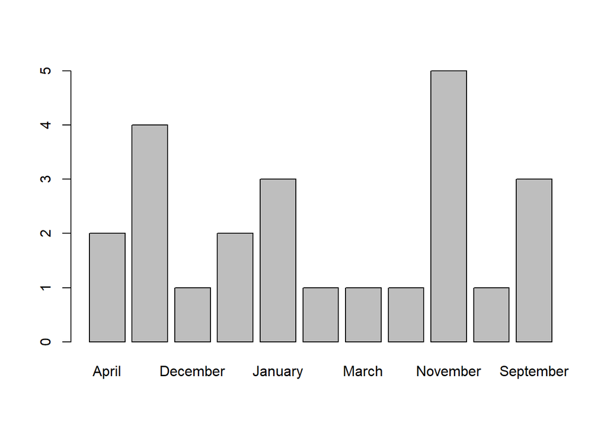

```r
## A vector containing different months
mons <- c("March","April","January","November","January", "September","October","September","November","August","January","November",
          "November","February","May","August",   "July","December","August","August","September","November", "February","April")

## Convert it to a factor
mons_unordered = factor(mons)

## Notice the factor defaults to alphabetical order
barplot(table(mons_unordered))
```

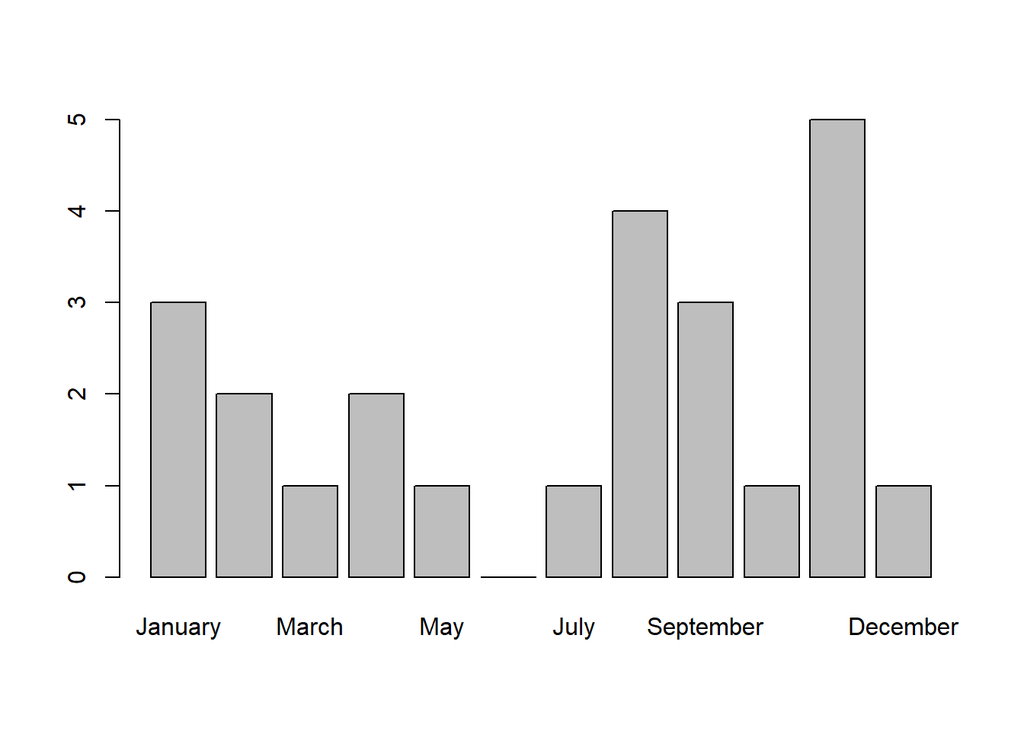

```r
## Convert to a factor with ordering specified by the "levels" argument
mons_ordered = factor(mons_unordered, levels= c("January","February","March","April","May","June",
                                                "July","August","September","October","November","December"),
                        ordered = TRUE)

## Notice the new ordering (useful for data visualization!)
barplot(table(mons_ordered))
```

**Question 10**:

The code below loads the “colleges” data set. Recall that this data set contains information pertaining to all primarily undergraduate institutions with at least 400 full-times students in the 2019-20 academic year.

```r
colleges <- read.csv("https://remiller1450.github.io/data/Colleges2019.csv")
```

- **Part A**: Create a subset of these (the?) data that contains all schools that admit less than 50% of applicants (an “Adm_Rate” less than 50%) and are located in the “Great Lakes” region. You should use this subset in Parts B and C.
- **Part B**: Using the subset created in Part A, find the average value of “Salary10yr_median”, the median salary of a school’s alumni 10 years after their graduation. Remove missing data if necessary, but be sure to report the identity of any colleges that were removed.
- **Part C**: The “Great Lakes” region consists of 5 different states: IL, IN, MI, OH, and WI. Using the subset created in Part A, create a bar plot that displays the number of colleges (meeting the criteria specified in Part A) in each of these states in descending order (you may examine the frequency table to determine this ordering “by hand”).

## Loading Multiple Files

**Question 11A**: Download the data from [this folder](https://remiller1450.github.io/data/experiment.zip) of data files to your Lab Data folder. Run the following line (rewrite it to match your username) to verify the .xlsx files are there. You may have to extract from a .zip file and rename the folder from Experiments->Data.

```r
list.files(path = "C:/Users/friedrichsen/OneDrive - Grinnell College/Documents/STA230_F25/Labs/Data")
```

```
## [1] "run18_treatment.xlsx" "run21_control.xlsx"   "run34_control.xlsx"
## [4] "run35_treatment.xlsx"
```

Now let’s suppose we want to find the means of the variable “VDS.Veh.Speed” for each participant file. Note that these are excel files (not .csv files), so we must first load (and possibly install) the `readxl` package in order to read them into `R`.

We then can *iterate* through these files using a for loop, storing the mean of each participant:

```r
library(readxl)
my_dir = "C:/Users/friedrichsen/OneDrive - Grinnell College/Documents/STA230_F25/Labs/Data"
my_files <- list.files(path = my_dir)  ## List of file names in your directory

means <- numeric(length(my_files))                           ## Set up storage object
for(i in 1:length(my_files)){                                ## Loop over each file
  temp <- read_excel(paste0(my_dir, "/", my_files[i]))       ## Read by appending file name to the path prefix using paste0()
  means[i] <- mean(temp$VDS.Veh.Speed)                       ## Store the mean of the current file
}
print(means)
```

```
## [1] 24.91347 35.62761 56.93149 26.81412
```

**Question 11B**: Using the example above as a template, find the standard deviations (using the `sd()` function) of each participant file. Store these standard deviations in an object named “sds” and print them as part of your answer.

## Row Binding

Sometimes it can be useful to aggregate several data frames with the same structure into one larger data frame. For example, we might want to combine all four participant files from Question #11 into a combined data frame. Or, perhaps we want to aggregate several years of data from the same source. These tasks can be handled by the `rbind()` function, which will append the rows of one or more data frames to an initial data frame (provided the column names match):

```r
df1 <- data.frame(Year = 2019, val = rnorm(3))
df2 <- data.frame(Year = 2020, val = rnorm(3, mean = 10))

rbind(df1, df2)
```

```
##   Year        val
## 1 2019  2.4825346
## 2 2019 -2.1959751
## 3 2019 -0.9816842
## 4 2020  9.9810198
## 5 2020  9.5435442
## 6 2020 10.5744144
```

Note that this result could also be achieved using `full_join()` (though I personally find that approach less intuitive). However, `rbind()` has the advantage of easily being able to bind an arbitrary number of data frames in a single command:

```r
full_join(x = df1, y = df2)
```

```r
df3 <- data.frame(Year = 2021, val = rnorm(3, mean = -5)) ## How about a third year?
rbind(df1, df2, df3)
```

```
##   Year        val
## 1 2019  2.4825346
## 2 2019 -2.1959751
## 3 2019 -0.9816842
## 4 2020  9.9810198
## 5 2020  9.5435442
## 6 2020 10.5744144
## 7 2021 -5.2712497
## 8 2021 -5.6158131
## 9 2021 -4.2398876
```

**Question 12**: In the `colleges` dataset, find the rows for Iowa State University and Grinnell College. Make two data frames consisting of each row of data respectively. Use `rbind()` to combine these into a new data frame.

## Practice (Required!)

**Question 13**:

*The College Scorecard* is a government database that record various characteristics of accredited colleges and universities within the United States. A portion of this database containing 2019-2020 data on colleges that primarily award undergraduate degrees and had at least 400 full time students is available at the URL below:

https://remiller1450.github.io/data/Colleges2019.csv

**Part A**: Load these data into `R` and store them as a data.frame object named `colleges`.

**Part B**: Create a subset of `colleges` that admit fewer than 25% of applicants (as measured by “Adm_Rate”). Store this subject in an object named `colleges_selective`.

**Part C**: Using the subset you created in Part B, `colleges_selective`, construct a table containing the proportion of private colleges within each region.

**Part D**: Provide a 1-sentence interpretation of one of the proportions in your table (you may choose which one seems most interesting).

**Question 14**:

The data available at the URL below contains information from the Ames Assessor’s Office used in computing assessed values for individual residential properties sold in Ames, IA from 2006 to 2010:

https://remiller1450.github.io/data/AmesHousing.csv

A more detailed description can be found at [this link](https://jse.amstat.org/v19n3/decock/DataDocumentation.txt).

**Part A**: Read these data into `R` and store in a data frame named `ames_housing`. Then check the type of the variable `MS.SubClass` and compare it with the description of this variable given in the link above. Based upon your assessment, should this variable coerced to a different type? Briefly explain.

**Part B**: Find the number of homes in this data set with missing values for the variable `Garage.Type`. Hint: you can use the `sum()` function on a logical vector to count the number of `TRUE` values.

**Part C**: Create a subset containing homes with a missing value for the variable `Garage.Type`. What is the average `Garage.Area` of these homes?

**Part D**: Using the variable `Exter.Cond` (exterior condition), create an ordered factor that goes from “Poor” condition (a value of `Po`) to “Excellent” condition (a value of `Ex`) following the order and definitions given in the detailed description for this variable. Use the `barplot()` and `table()` functions to construct a bar chart using your ordered factor variable.